# Machine Learning ETE Question 4

## Why this combination?

- PCA is an appropriate unsupervised dimensionality-reduction method for continuous, correlated numeric variables. Standardisation is required because PCA is scale-sensitive.
- Random Forest Regressor is an ensemble of decision trees that models non-linear relationships and feature interactions with little tuning.
- PCA is fitted inside a Pipeline, so it learns only from the training split and cannot leak test-set information. The baseline shows whether reduction is worthwhile for this small, eight-feature dataset.

```python
import time

import matplotlib.pyplot as plt
import numpy as np
import pandas as pd
from sklearn.datasets import fetch_california_housing
from sklearn.decomposition import PCA
from sklearn.ensemble import RandomForestRegressor
from sklearn.impute import SimpleImputer
from sklearn.metrics import mean_squared_error, r2_score
from sklearn.model_selection import train_test_split
from sklearn.pipeline import Pipeline
from sklearn.preprocessing import StandardScaler

RANDOM_STATE = 42
```

```python
housing = fetch_california_housing(as_frame=True)
X, y = housing.data, housing.target

print(f'Samples: {X.shape[0]:,}')
print(f'Original features: {X.shape[1]}')
display(X.head())
```

```
Samples: 20,640
Original features: 8
```

|  | MedInc | HouseAge | AveRooms | AveBedrms | Population | AveOccup | Latitude | Longitude |
| --- | --- | --- | --- | --- | --- | --- | --- | --- |
| 0 | 8.3252 | 41.0 | 6.984127 | 1.023810 | 322.0 | 2.555556 | 37.88 | -122.23 |
| 1 | 8.3014 | 21.0 | 6.238137 | 0.971880 | 2401.0 | 2.109842 | 37.86 | -122.22 |
| 2 | 7.2574 | 52.0 | 8.288136 | 1.073446 | 496.0 | 2.802260 | 37.85 | -122.24 |
| 3 | 5.6431 | 52.0 | 5.817352 | 1.073059 | 558.0 | 2.547945 | 37.85 | -122.25 |
| 4 | 3.8462 | 52.0 | 6.281853 | 1.081081 | 565.0 | 2.181467 | 37.85 | -122.25 |

## Exploratory Data Analysis

```python
eda_summary = pd.DataFrame({
    'Data type': X.dtypes.astype(str),
    'Missing values': X.isna().sum(),
    'Unique values': X.nunique(),
})
display(eda_summary)
display(X.describe().T)
print(f'Target mean: ${y.mean() * 100_000:,.0f}')
print(f'Target range: ${y.min() * 100_000:,.0f} to ${y.max() * 100_000:,.0f}')
```

|  | Data type | Missing values | Unique values |
| --- | --- | --- | --- |
| MedInc | float64 | 0 | 12928 |
| HouseAge | float64 | 0 | 52 |
| AveRooms | float64 | 0 | 19392 |
| AveBedrms | float64 | 0 | 14233 |
| Population | float64 | 0 | 3888 |
| AveOccup | float64 | 0 | 18841 |
| Latitude | float64 | 0 | 862 |
| Longitude | float64 | 0 | 844 |

|  | count | mean | std | min | 25% | 50% | 75% | max |
| --- | --- | --- | --- | --- | --- | --- | --- | --- |
| MedInc | 20640.0 | 3.870671 | 1.899822 | 0.499900 | 2.563400 | 3.534800 | 4.743250 | 15.000100 |
| HouseAge | 20640.0 | 28.639486 | 12.585558 | 1.000000 | 18.000000 | 29.000000 | 37.000000 | 52.000000 |
| AveRooms | 20640.0 | 5.429000 | 2.474173 | 0.846154 | 4.440716 | 5.229129 | 6.052381 | 141.909091 |
| AveBedrms | 20640.0 | 1.096675 | 0.473911 | 0.333333 | 1.006079 | 1.048780 | 1.099526 | 34.066667 |
| Population | 20640.0 | 1425.476744 | 1132.462122 | 3.000000 | 787.000000 | 1166.000000 | 1725.000000 | 35682.000000 |
| AveOccup | 20640.0 | 3.070655 | 10.386050 | 0.692308 | 2.429741 | 2.818116 | 3.282261 | 1243.333333 |
| Latitude | 20640.0 | 35.631861 | 2.135952 | 32.540000 | 33.930000 | 34.260000 | 37.710000 | 41.950000 |
| Longitude | 20640.0 | -119.569704 | 2.003532 | -124.350000 | -121.800000 | -118.490000 | -118.010000 | -114.310000 |

```
Target mean: $206,856
Target range: $14,999 to $500,001
```

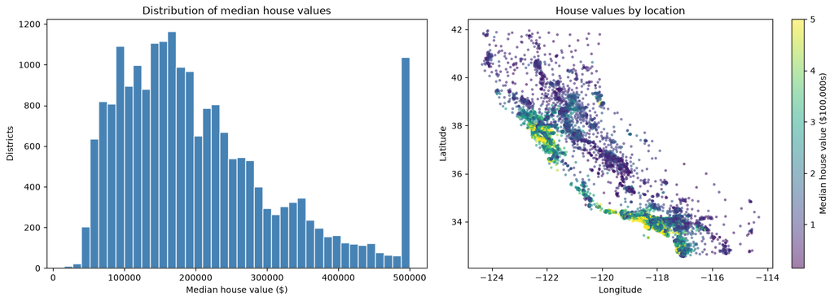

```python
fig, axes = plt.subplots(1, 2, figsize=(14, 5))
axes[0].hist(y * 100_000, bins=40, color='steelblue', edgecolor='white')
axes[0].set(title='Distribution of median house values', xlabel='Median house value ($)', ylabel='Districts')

price_map = axes[1].scatter(X['Longitude'], X['Latitude'], c=y, cmap='viridis', s=5, alpha=0.5)
axes[1].set(title='House values by location', xlabel='Longitude', ylabel='Latitude')
fig.colorbar(price_map, ax=axes[1], label='Median house value ($100,000s)')
plt.tight_layout()
plt.show()
```

## Preprocessing Checks

```python
preprocessing_checks = pd.Series({
    'Missing feature values': int(X.isna().sum().sum()),
    'Duplicate feature rows': int(X.duplicated().sum()),
    'Non-numeric features': X.select_dtypes(exclude=np.number).shape[1],
    'Largest/smallest feature standard-deviation ratio': X.std().max() / X.std().min(),
})
display(preprocessing_checks.to_frame('Result').round(2))
print('Scaling before PCA is required:', preprocessing_checks.iloc[-1] > 10)
```

|  | Result |
| --- | --- |
| Missing feature values | 0.00 |
| Duplicate feature rows | 0.00 |
| Non-numeric features | 0.00 |
| Largest/smallest feature standard-deviation ratio | 2389.61 |

```
Scaling before PCA is required: True
```

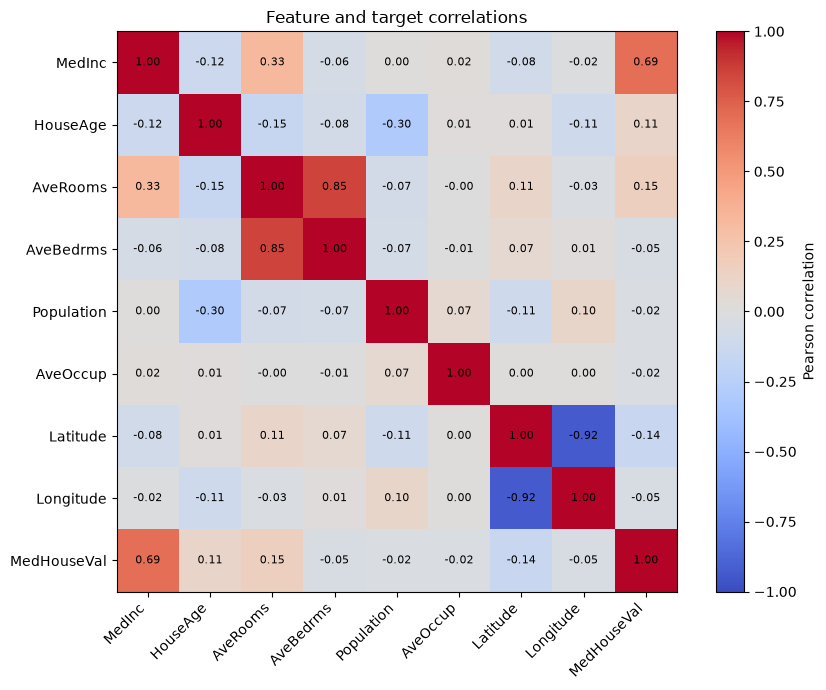

```python
correlation = X.assign(MedHouseVal=y).corr(numeric_only=True)
fig, ax = plt.subplots(figsize=(9, 7))
heatmap = ax.imshow(correlation, cmap='coolwarm', vmin=-1, vmax=1)
ax.set_xticks(range(len(correlation)), correlation.columns, rotation=45, ha='right')
ax.set_yticks(range(len(correlation)), correlation.index)
for row, column in np.ndindex(correlation.shape):
    ax.text(column, row, f'{correlation.iloc[row, column]:.2f}', ha='center', va='center', fontsize=8)
fig.colorbar(heatmap, ax=ax, label='Pearson correlation')
ax.set_title('Feature and target correlations')
plt.tight_layout()
plt.show()
```

```python
X_train, X_test, y_train, y_test = train_test_split(
    X, y, test_size=0.2, random_state=RANDOM_STATE
)

baseline = RandomForestRegressor(
    n_estimators=200, random_state=RANDOM_STATE, n_jobs=-1
)
pca_preprocessor = Pipeline([
    ('impute', SimpleImputer(strategy='median')),
    ('scale', StandardScaler()),
])
pca_forest = Pipeline([
    ('preprocess', pca_preprocessor),
    ('pca', PCA(n_components=0.95, random_state=RANDOM_STATE)),
    ('forest', RandomForestRegressor(
        n_estimators=200, random_state=RANDOM_STATE, n_jobs=-1
    )),
])
```

```python
results = []
for name, model, feature_count in [
    ('Random Forest (baseline)', baseline, X_train.shape[1]),
    ('PCA (95%) + Random Forest', pca_forest, None),
]:
    start = time.perf_counter()
    model.fit(X_train, y_train)
    fit_seconds = time.perf_counter() - start
    predictions = model.predict(X_test)
    if feature_count is None:
        feature_count = model.named_steps['pca'].n_components_
    results.append({
        'Model': name,
        'Features used': feature_count,
        'Variance retained': 1.0 if name.startswith('Random') else model.named_steps['pca'].explained_variance_ratio_.sum(),
        'R²': r2_score(y_test, predictions),
        'RMSE': mean_squared_error(y_test, predictions) ** 0.5,
        'Fit time (s)': fit_seconds,
    })

comparison = pd.DataFrame(results).set_index('Model')
assert np.isfinite(comparison[['R²', 'RMSE', 'Fit time (s)']].to_numpy()).all()
display(comparison.round(4))
```

| Model | Features used | Variance retained | R² | RMSE | Fit time (s) |
| --- | --- | --- | --- | --- | --- |
| Random Forest (baseline) | 8 | 1.0000 | 0.8059 | 0.5043 | 3.1555 |
| PCA (95%) + Random Forest | 6 | 0.9837 | 0.6437 | 0.6833 | 2.8340 |

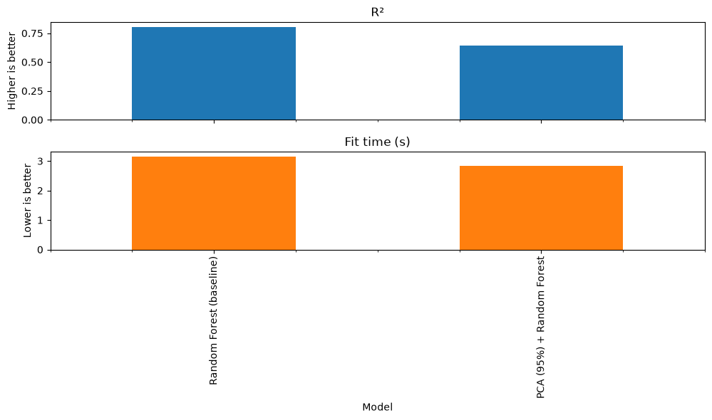

```python
ax = comparison[['R²', 'Fit time (s)']].plot.bar(subplots=True, legend=False, figsize=(10, 6))
ax[0].set_ylabel('Higher is better')
ax[1].set_ylabel('Lower is better')
plt.tight_layout()
plt.show()
```

## Discussion

- **Accuracy:** PCA may improve generalisation when noisy or highly collinear features dominate. It can also lower R² here because principal components preserve feature variance, not their relationship with house price. Use the displayed hold-out R² and RMSE to choose the better model.
- **Computation cost:** retaining 95% of variance reduces the number of inputs evaluated at each tree split, which can reduce memory and fitting cost for wide datasets. On this dataset PCA itself adds a small upfront cost and only eight features exist, so the baseline can be just as fast or faster.
- **Interpretability:** the baseline's feature importances refer to original variables such as `MedInc` and `AveRooms`. PCA features are weighted mixtures of those variables, so the PCA pipeline is less directly interpretable even when accuracy is similar.

**Conclusion:** keep PCA + Random Forest only if its validation performance is comparable or better and dimensionality reduction is valuable. For these eight original features, the baseline is usually easier to explain.